# Question

Let’s consider an alternative way to multiply 87 and 63.

First, let’s break each number into its tens and ones.

$$87 ~~=~~ 80+7$$
$$63 ~~=~~ 60+3$$

Now, find all 4 indicated products. Also, find the totals.

| * | $80$ | $7$ | **total** |
| --- | --- | --- | --- |
| $60$ | ##ANSWER1## | ##ANSWER2## | ##ANSWER5## |
| $3$ | ##ANSWER3## | ##ANSWER4## | ##ANSWER6## |
| **total** | ##ANSWER7## | ##ANSWER8## | ##ANSWER9## |

## Answerlist

- 48
- 480
- 4800
- 48000
- 42
- 420
- 4200
- 42000
- 24
- 240
- 2400
- 24000
- 21
- 210
- 2100
- 21000
- 261
- 441
- 5040
- 5220
- 5481
- 261
- 441
- 5040
- 5220
- 5481
- 261
- 441
- 5040
- 5220
- 5481
- 261
- 441
- 5040
- 5220
- 5481
- 261
- 441
- 5040
- 5220
- 5481

# Solution

$$87\cdot 63 = 5481$$

| * | $80$ | $7$ | **total** |
| --- | --- | --- | --- |
| $60$ | 4800 | 420 | 5220 |
| $3$ | 240 | 21 | 261 |
| **total** | 5040 | 441 | 5481 |

At some point I learned about the [multiplication by lines](https://www.mathnstuff.com/math/spoken/here/2class/60/bylines.htm) method. You’ll notice there are 8 lines above 7 lines, both with positive slope. There are also 6 lines above 3 lines, both with negative slope. The number of intersections in the four corners are found with multiplication: $8\cdot6=48$ and $7\cdot6=42$ and $8\cdot3=24$ and $7\cdot3=21$.

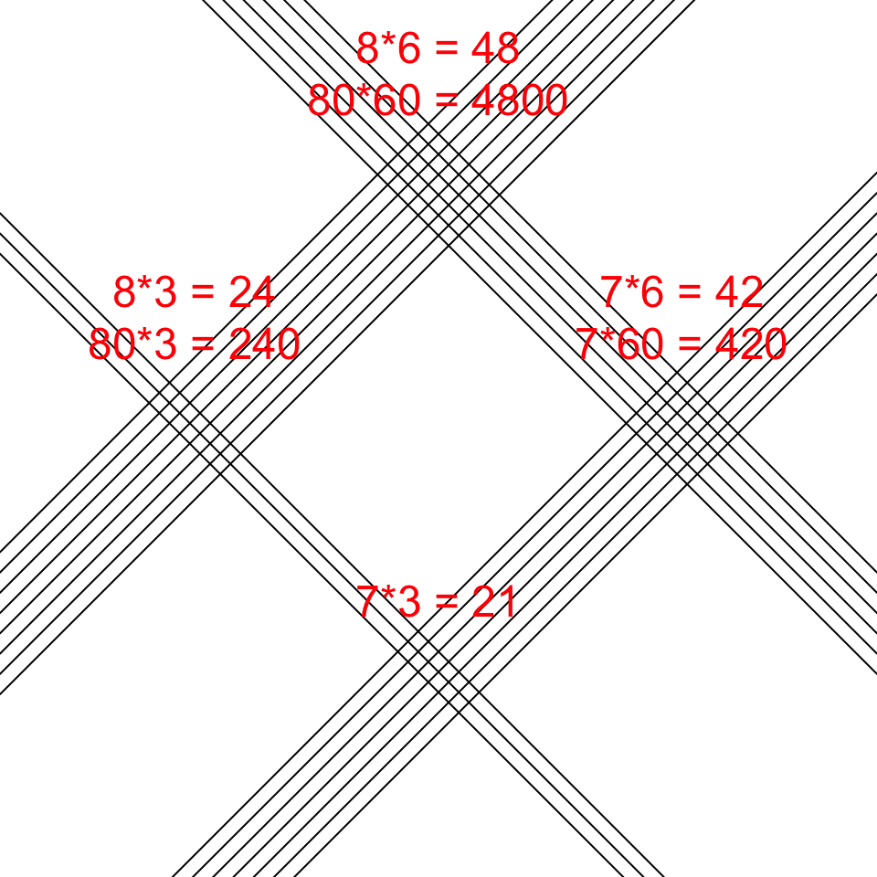

$$4800 + 420 + 240 + 21 ~~=~~
5481$$

# Meta-information

extype: cloze exclozetype: schoice|schoice|schoice|schoice|schoice|schoice|schoice|schoice|schoice exsolution: 0010|0100|0100|1000|00010|10000|00100|01000|00001 exname: multiply_2digits